# Import the Libraries

# What is the relationship between category count and price?

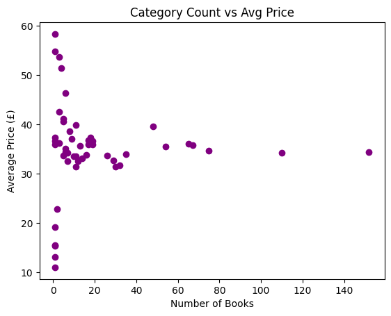

```python
cat_summary = df.groupby('Category').agg({'Price':'mean','Title':'count'}).rename(columns={'Title':'Count'})
plt.scatter(cat_summary['Count'], cat_summary['Price'], color='purple')
plt.title("Category Count vs Avg Price")
plt.xlabel("Number of Books")
plt.ylabel("Average Price (£)")
plt.show()
```

- Categories with high count and high price are strong performers.
- High count but low price competitive, low-margin genres.
- Low count and high price niche, premium genres.
- Reveals market 1structure in the dataset.

# Price trend by category and rating (heatmap)

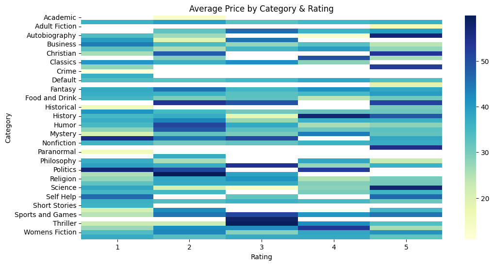

```python
pivot = df.pivot_table(values='Price', index='Category', columns='Rating', aggfunc='mean')
plt.figure(figsize=(12,6))
sns.heatmap(pivot, cmap='YlGnBu')
plt.title("Average Price by Category & Rating")
plt.show()
```

- Visualizes multi-dimensional pricing patterns.
- Some categories have high-rated books with premium prices.
- Others show stable prices across all ratings.
- Reveals pricing sensitivity per genre.
- Useful for predicting ideal price bands by rating and category.
- It Shows how price varies with rating across categories.
- Some categories maintain high prices even at average ratings, suggesting brand or content value.

# KDE & Boxplot for Outlier Detection

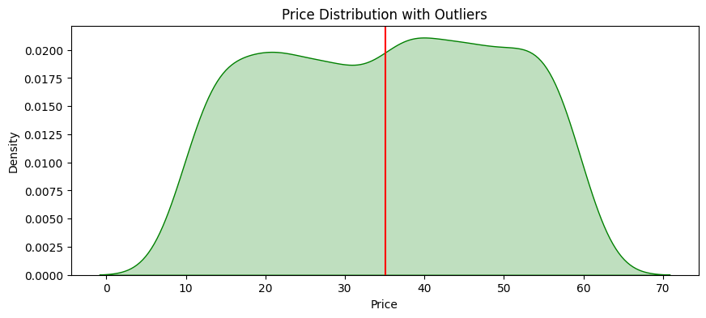

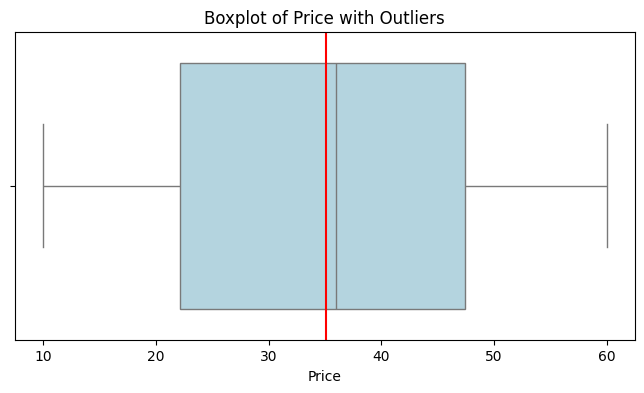

```python
plt.figure(figsize=(10,4))
sns.kdeplot(data=df, x='Price', fill=True, color='green')
plt.title("Price Distribution with Outliers")
plt.axvline(df['Price'].mean(), color='red')
plt.show()

plt.figure(figsize=(8,4))
sns.boxplot(data=df, x='Price', color='lightblue')
plt.title("Boxplot of Price with Outliers")
plt.axvline(df['Price'].mean(), color='red')
plt.show()
```

# Is there a relationship between rating and price?

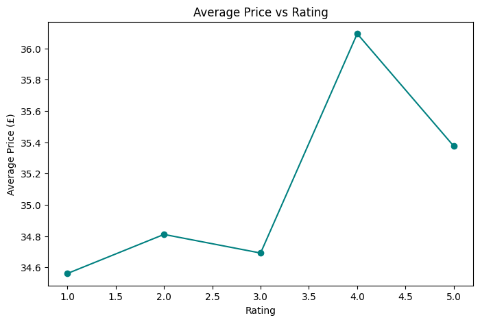

```python
plt.figure(figsize=(8,5))
df.groupby('Rating')['Price'].mean().plot(marker='o', color='teal')
plt.title('Average Price vs Rating')
plt.xlabel('Rating')
plt.ylabel('Average Price (£)')
plt.show()
```

- Books with a 4-star rating have the highest average price.
- Prices are not directly linked to ratings overall.
- High-rated books may be priced slightly higher due to better quality or demand.

# Correlation matrix of numeric variables¶

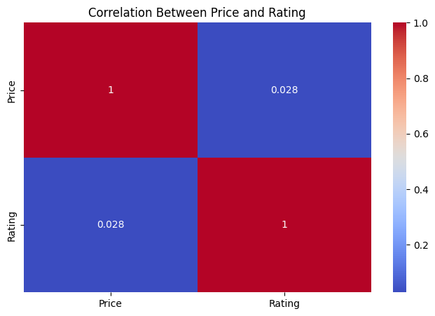

```python
plt.figure(figsize=(8,5))
sns.heatmap(df[['Price','Rating']].corr(), annot=True, cmap='coolwarm')
plt.title('Correlation Between Price and Rating')
plt.show()
```

- The correlation value between price and rating is very low (0.028), showing almost no relationship between them.
- This means expensive books don’t necessarily receive higher ratings, and cheaper books can still perform well in customer satisfaction.
- The store should focus on book quality and content, not just pricing, to improve ratings and sales.